# HW5_part1

Zirui Liu

4/27/2018

# 1.Daily timeseries plot

1.1 Air Temperature

From 1987 to 2017 (data of 2011,12,13 was replaced by the nearby buoy)

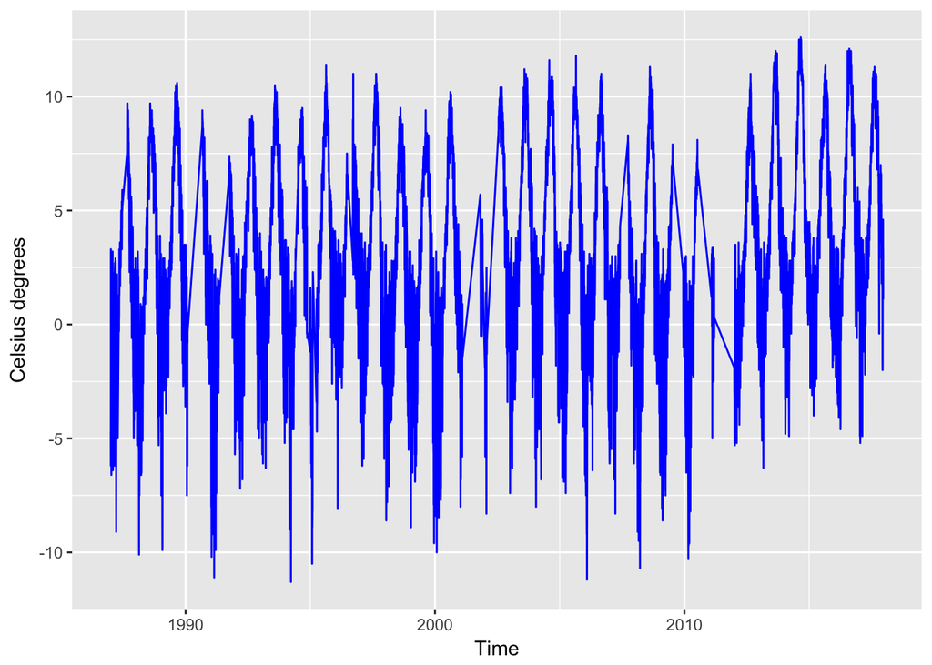

# 1.Daily timeseries plot

1.2 Water Temperature

From 1987 to 2017 (data of 2011,12,13 was replaced by the nearby buoy)

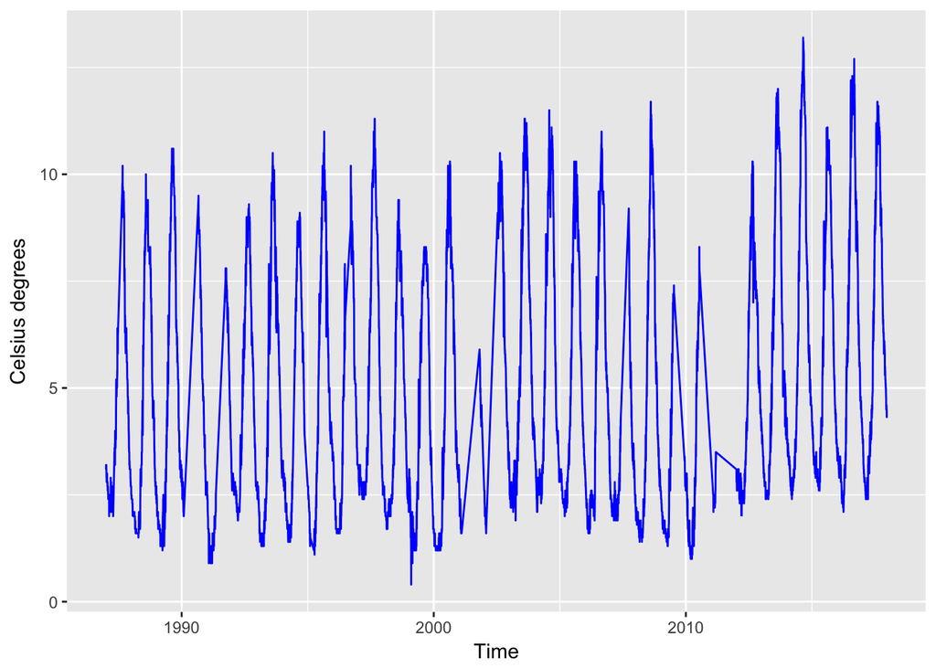

# 2.Statistics

2.1.1 test on ATMP

```
##
##  Welch Two Sample t-test
##
## data:  data_1987$ATMP and data_2017$ATMP
## t = -48.09, df = 14831, p-value < 2.2e-16
## alternative hypothesis: true difference in means is not equal to 0
## 95 percent confidence interval:
##  -3.148340 -2.901742
## sample estimates:
## mean of x mean of y
##  1.791048  4.816089
```

# 2.Statistics

2.1.2 test on WTMP

```
##
##  Welch Two Sample t-test
##
## data:  data_1987$WTMP and data_2017$WTMP
## t = -42.922, df = 15060, p-value < 2.2e-16
## alternative hypothesis: true difference in means is not equal to 0
## 95 percent confidence interval:
##  -1.882676 -1.718232
## sample estimates:
## mean of x mean of y
##  4.356665  6.157119
```

Thus, there are significant changes in the past 30 years. But we also want to know which direction did the atmp and wtmp move towards.

# 2.1.3 Regression

Using regression line to show the direction of changing

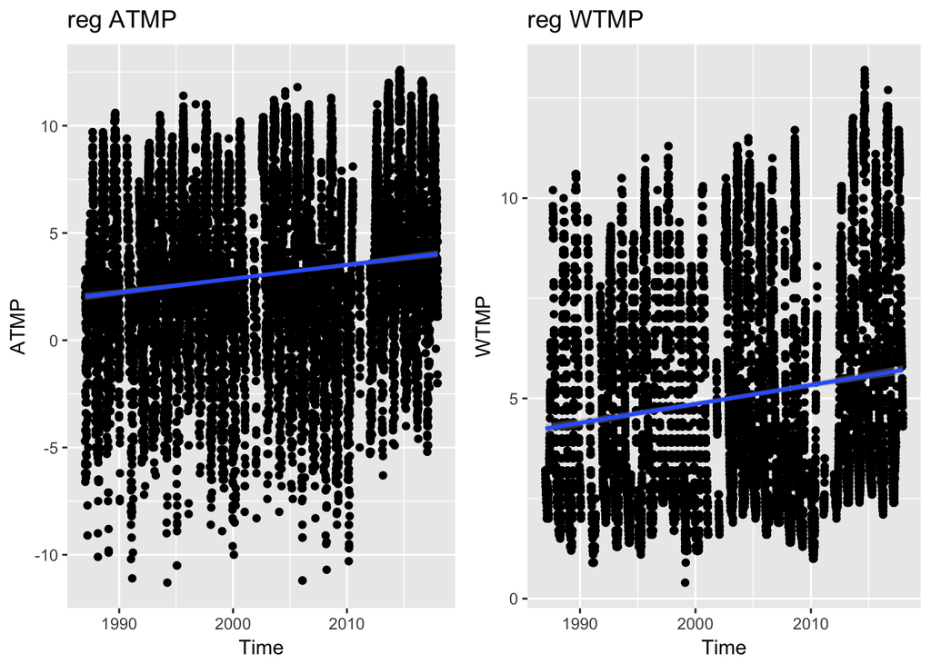

We can see a clear upward trend of the ATMP and WTMP from the regression line, which indicates that the global warming exists!

# 3.Sampling Affection

Test whether sampling affected your evaluation of temperature change

3.1 Hourly ATMP and WTMP

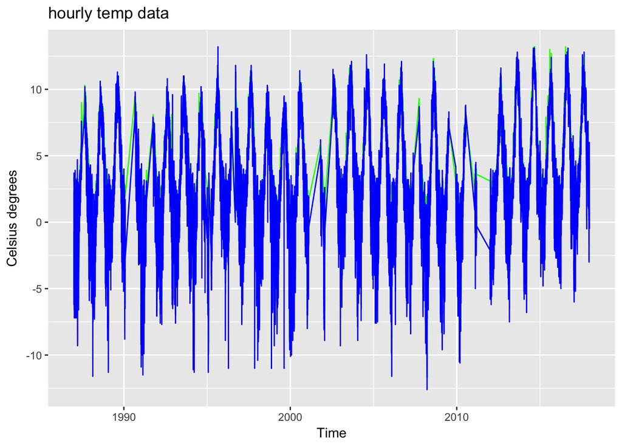

# 3.Sampling Affection

3.2 Compare hourly data with daily data:

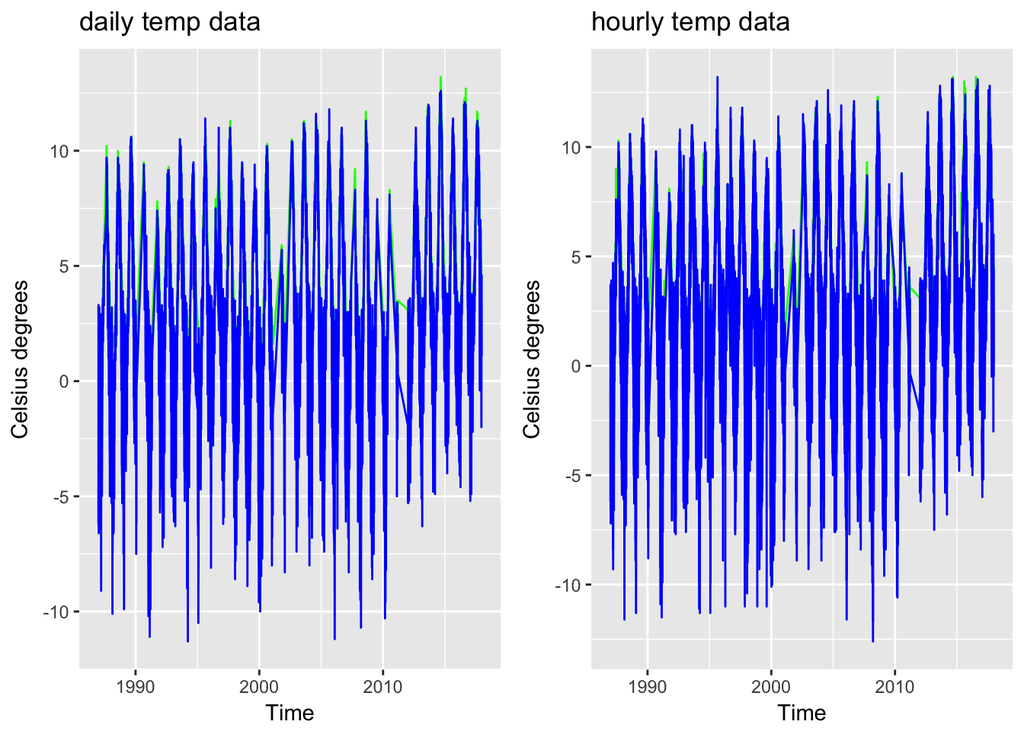

As we can see in the above pictures, they are nearly the same, while the hourly graph takes more times to load and run, So we’d better use daily data rather than hourly.